# Caption Demo

Rebecca Ferrell

April 11, 2016

In this document, I will demonstrate two ways of producing captions. The first uses the `gridExtra` package to draw it right on the plot, and the second uses R Markdown’s captioning features. The first approach is manual and a bit fussy, while the second approach is simpler but less customizable.

## gridExtra

The `gridExtra` package lets you combine multiple plots into a single image (separate from any `ggplot2` faceting) and add annotations. Each piece of the overall plot is called a *grob*. You can add `ggplot` grobs as well as text. Here is an example where we add a “master” title and a caption below.

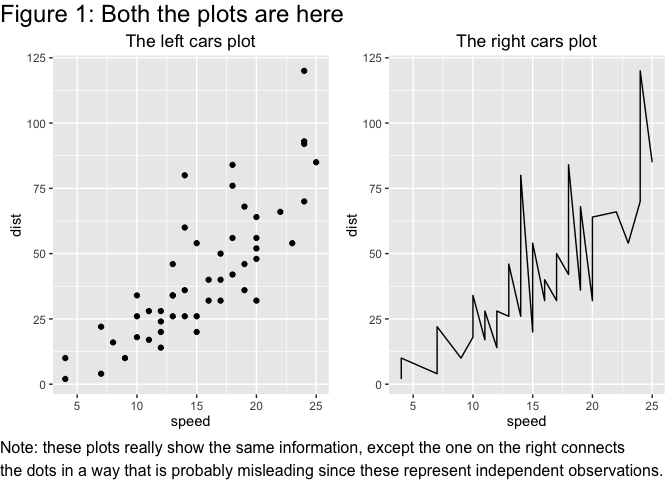

```r
# install.packages("gridExtra")
library(ggplot2)
library(gridExtra)
library(grid)

# store your plots as objects
plot_1 <- ggplot(data = cars, aes(x = speed, y = dist)) +
    geom_point() +
    ggtitle("The left cars plot")
plot_2 <- ggplot(data = cars, aes(x = speed, y = dist)) +
    geom_line() +
    ggtitle("The right cars plot")

# put side-by-side
grid.arrange(plot_1, plot_2, ncol=2,
             top = textGrob("Figure 1: Both the plots are here",
                            x = 0, # starts far left
                            y = 0.5, # experiment with
                                     # vertical placement
                            just = "left", # left-aligned,
                            gp = gpar(fontsize = 18) # bigger font
             ),
             bottom = textGrob("Note: these plots really show the same information, except the one on the right connects\nthe dots in a way that is probably misleading since these represent independent observations.",
                           x = 0,
                           y = 0.5,
                           just = "left"))
```

## R Markdown captions

Alternatively, you can use R Markdown’s figure and captioning features. To activate this, add `fig_caption: true` to your YAML header like so:

```
---
title: "Caption Demo"
author: "Rebecca Ferrell"
date: "April 11, 2016"
output:
  html_document:
    fig_caption: true
---
```

Then in your chunk where you make the plot, put a `fig.cap` argument in your chunk options (along with things like `echo=FALSE`, etc.), e.g. `fig.cap="Note: this is my second figure, captioned using Markdown."`.

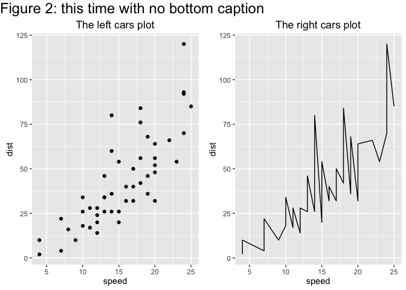

Note: this is my second figure, captioned using Markdown.

```r
grid.arrange(plot_1, plot_2, ncol=2,
             top = textGrob("Figure 2: this time with no bottom caption",
                            x = 0, y = 0.5,
                            just = "left",
                            gp = gpar(fontsize = 18)))
```